# LogisticRegression

### Logistic Regression with all the variables

• Fitting Logistic regression model using glm function in stats package. The link function uses binomial family.

• The data has been split into train and test set as 70% and 30%.

• The table below shows log odds (estimate), standard error, z value and p-value for each variable.

• The rows highlighted in green show variables with p-values <= 0.05.

• The rows highlighted in orange show variables with p-values > 0.05 and < 0.1.

|  | Estimate | Std. Error | z value | Pr(>\|z\|) |
| --- | --- | --- | --- | --- |
| (Intercept) | 5.4520745 | 1.8413719 | 2.9608763 | 0.0030677 |
| Status_checking_accountlt_0 | -1.6751472 | 0.2940062 | -5.6976584 | 0.0000000 |
| Status_checking_accountlt_200 | -1.4385680 | 0.2959960 | -4.8600934 | 0.0000012 |
| Status_checking_accountgte_200 | -0.8396912 | 0.4826542 | -1.7397368 | 0.0819052 |
| Duration_in_month | -0.0343487 | 0.0113435 | -3.0280383 | 0.0024615 |
| Credit_historydelayed_in_past | -0.7302459 | 0.4357914 | -1.6756776 | 0.0938014 |
| Credit_historyNo_credit_due | -1.5606813 | 0.5784593 | -2.6979967 | 0.0069758 |
| Credit_historyAll_paid_duly | -1.9593229 | 0.5567546 | -3.5191861 | 0.0004329 |
| Credit_historyAll_existing_paid_duly | -0.8386682 | 0.3380457 | -2.4809312 | 0.0131040 |
| PurposeBusiness | 0.6384011 | 1.0041072 | 0.6357898 | 0.5249135 |
| PurposeEducation | 0.3839566 | 1.0379834 | 0.3699062 | 0.7114524 |
| PurposeFurniture | 0.5822469 | 0.9554409 | 0.6094013 | 0.5422585 |
| PurposeNew.car | -0.1735148 | 0.9504725 | -0.1825563 | 0.8551461 |
| PurposeOthers | 1.2779069 | 1.3776265 | 0.9276149 | 0.3536074 |
| PurposeRepairs | -0.5891567 | 1.1485350 | -0.5129637 | 0.6079767 |
| PurposeRetraining | 1.0142753 | 1.5844988 | 0.6401238 | 0.5220921 |
| PurposeTelevision | 0.6895006 | 0.9438454 | 0.7305229 | 0.4650706 |
| PurposeUsed.car | 1.6842166 | 1.0275806 | 1.6390118 | 0.1012108 |
| Credit_amount | -0.0001476 | 0.0000544 | -2.7148362 | 0.0066309 |
| Savings_account_bondslt_100 | -1.3230824 | 0.3507816 | -3.7718125 | 0.0001621 |
| Savings_account_bonds100_500 | -0.7468545 | 0.4671602 | -1.5987119 | 0.1098846 |
| Savings_account_bonds500_1000 | -0.3617776 | 0.6042654 | -0.5987064 | 0.5493687 |
| Savings_account_bondsgt_1000 | 0.5837776 | 0.7562564 | 0.7719308 | 0.4401554 |
| Present_employment_since1_yr | -0.9838883 | 0.5609071 | -1.7541021 | 0.0794130 |
| Present_employment_since4_yr | -0.4249302 | 0.5366343 | -0.7918431 | 0.4284521 |
| Present_employment_since7_yr | 0.2522416 | 0.5739339 | 0.4394960 | 0.6603022 |
| Present_employment_sincegt_7_yr | -0.0081402 | 0.5375098 | -0.0151444 | 0.9879170 |
| Installment_rate_in_percentage_of_disp_income20_25 | 0.5104665 | 0.3169243 | 1.6106890 | 0.1072475 |
| Installment_rate_in_percentage_of_disp_income25_35 | 0.9823180 | 0.3056430 | 3.2139386 | 0.0013093 |
| Installment_rate_in_percentage_of_disp_income35_plus | 1.0303528 | 0.3650657 | 2.8223763 | 0.0047669 |
| Personal_status_and_sexFemale.divorced | -0.0894416 | 0.4774098 | -0.1873477 | 0.8513881 |
| Personal_status_and_sexmale.single | 0.6707882 | 0.4672147 | 1.4357174 | 0.1510828 |
| Personal_status_and_sexmale.married | 0.0029365 | 0.5570466 | 0.0052716 | 0.9957939 |
| Guarantorsco_applicant | -0.6200040 | 0.5553047 | -1.1165113 | 0.2642033 |
| Guarantorsguarantor | 0.9658035 | 0.5182585 | 1.8635557 | 0.0623841 |
| Present_residence_since1_4yr | -1.1571427 | 0.3792462 | -3.0511653 | 0.0022796 |
| Present_residence_since4_7yr | -0.9382633 | 0.4234718 | -2.2156455 | 0.0267158 |
| Present_residence_sincegt_7_yr | -0.6238472 | 0.3857826 | -1.6170953 | 0.1058577 |
| PropertyReal.estate | 1.1084685 | 0.6652246 | 1.6663071 | 0.0956523 |
| Propertyinsurance | 0.9579977 | 0.6517785 | 1.4698209 | 0.1416103 |
| Propertycar | 0.7466409 | 0.6380833 | 1.1701306 | 0.2419484 |
| Age | -0.0039106 | 0.0111485 | -0.3507704 | 0.7257606 |
| Other_installment_plansbanks | -0.2292325 | 0.3041482 | -0.7536868 | 0.4510373 |
| Other_installment_plansstores | -0.1894101 | 0.5049805 | -0.3750840 | 0.7075980 |
| HousingRent | -0.9392773 | 0.7090614 | -1.3246769 | 0.1852783 |
| HousingOwn | -0.3796041 | 0.6770592 | -0.5606660 | 0.5750252 |
| Number_of_existing_credits_at_this_bank | -0.2826593 | 0.2576210 | -1.0971905 | 0.2725581 |
| JobUnskilled_Res | 0.3988288 | 0.7968198 | 0.5005257 | 0.6167049 |
| Jobskilled | 0.0971586 | 0.7669174 | 0.1266871 | 0.8991880 |
| Jobmanagement | 0.3629961 | 0.7714756 | 0.4705218 | 0.6379822 |
| Number_of_dependantsgt_2 | 0.4363896 | 0.3135280 | 1.3918678 | 0.1639624 |
| TelephoneYes | 0.4384479 | 0.2537192 | 1.7280837 | 0.0839732 |
| foreign_workerYes | -1.3105278 | 0.7757275 | -1.6894177 | 0.0911394 |

• Let’s look at the confusion matrix that shows actual labels in the columns and predicted labels in the rows

• The train and test set accuracy, sensitivity, specificity and F1 scores are shown in the tables below. ROC plotted below shows specificity (1-False Positive Rate) vs Sensitivity (True Positive Rate)

TRAIN FIT

|  | Bad | Good |
| --- | --- | --- |
| Bad | 141 | 89 |
| Good | 63 | 407 |

TRAIN FIT PERFORMANCE

| term | estimate |
| --- | --- |
| accuracy | 0.7828571 |
| kappa | 0.4932368 |
| sensitivity | 0.8205645 |
| specificity | 0.6911765 |
| pos_pred_value | 0.8659574 |
| neg_pred_value | 0.6130435 |
| precision | 0.8659574 |
| recall | 0.8205645 |
| f1 | 0.8426501 |
| prevalence | 0.7085714 |
| detection_rate | 0.5814286 |
| detection_prevalence | 0.6714286 |
| balanced_accuracy | 0.7558705 |

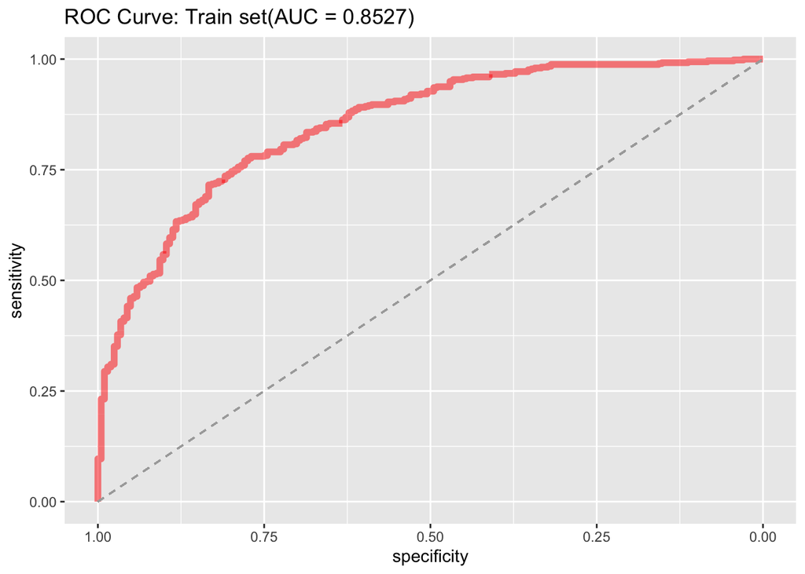

TEST FIT

|  | Bad | Good |
| --- | --- | --- |
| Bad | 59 | 42 |
| Good | 37 | 162 |

TEST FIT PERFORMANCE

| term | estimate |
| --- | --- |
| accuracy | 0.7366667 |
| kappa | 0.4031429 |
| sensitivity | 0.7941176 |
| specificity | 0.6145833 |
| pos_pred_value | 0.8140704 |
| neg_pred_value | 0.5841584 |
| precision | 0.8140704 |
| recall | 0.7941176 |
| f1 | 0.8039702 |
| prevalence | 0.6800000 |
| detection_rate | 0.5400000 |
| detection_prevalence | 0.6633333 |
| balanced_accuracy | 0.7043505 |

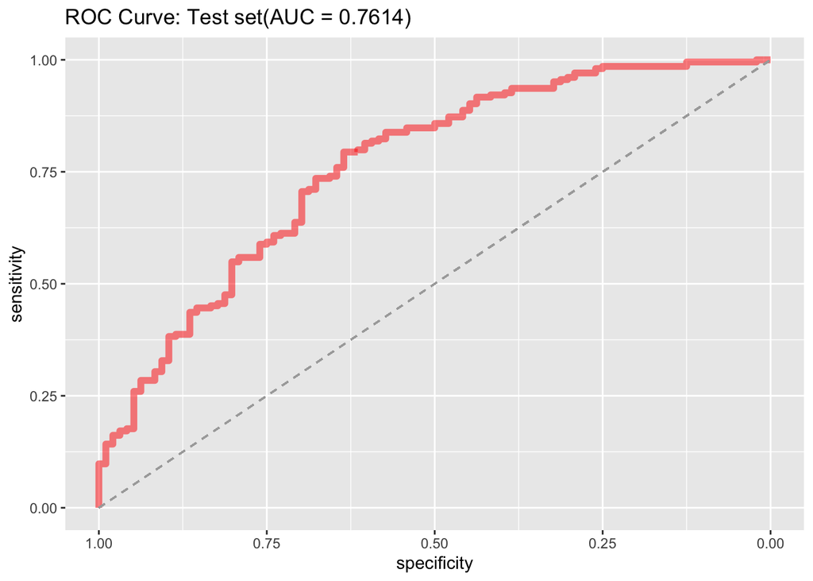

### LASSO on Logistic regression model

• Lasso regularization (shrinkage method) reduce or shrink the coefficients in the resulting regression to zero

• The plot below shows Lasso shrinkage parameter vs AUC. The lambda value (shrinkage parameter) used in the model is 0.03193 (log lambda of -3.444)

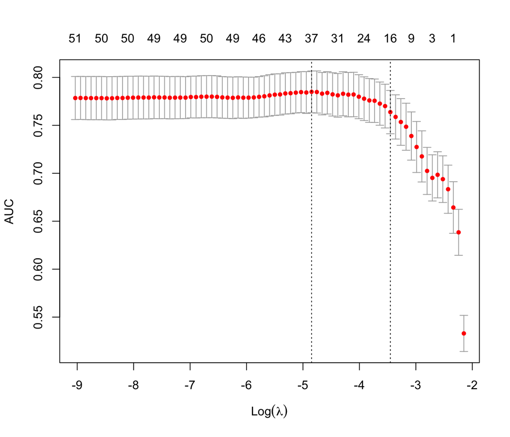

| Variable | Estimate |
| --- | --- |
| Status_checking_accountlt_0 | -0.9337732 |
| Status_checking_accountlt_200 | -0.5200555 |
| Duration_in_month | -0.0247893 |
| Credit_historyNo_credit_due | -0.4452870 |
| Credit_historyAll_paid_duly | -0.4790727 |
| PurposeNew.car | -0.1450933 |
| PurposeRepairs | -0.0854867 |
| PurposeUsed.car | 0.2970371 |
| Savings_account_bondslt_100 | -0.3697356 |
| Present_employment_since1_yr | -0.2957990 |
| Present_employment_since7_yr | 0.0098656 |
| Personal_status_and_sexmale.single | 0.1054979 |
| Guarantorsguarantor | 0.0795821 |
| Present_residence_since1_4yr | -0.0334718 |
| PropertyReal.estate | 0.1062426 |
| HousingOwn | 0.1483878 |

### Step-wise Variable Selection on Logistic Regression

• The step-wise regression (or step-wise selection) consists of iteratively adding and removing predictors, in the predictive model, in order to find the subset of variables in the data set resulting in the best performing model, that is a model that lowers prediction error.

• The table below shows variables with p-values < 0.1

|  | Estimate | Std..Error | z.value | Pr…z.. |
| --- | --- | --- | --- | --- |
| (Intercept) | 4.9380299 | 1.5600637 | 3.165275 | 0.0015494 |
| Status_checking_accountlt_0 | -1.6681000 | 0.2882517 | -5.786957 | 0.0000000 |
| Status_checking_accountlt_200 | -1.3836391 | 0.2903241 | -4.765843 | 0.0000019 |
| Status_checking_accountgte_200 | -0.8151839 | 0.4744355 | -1.718219 | 0.0857568 |
| Duration_in_month | -0.0354628 | 0.0108454 | -3.269848 | 0.0010761 |
| Credit_historydelayed_in_past | -0.7113401 | 0.4221231 | -1.685148 | 0.0919600 |
| Credit_historyNo_credit_due | -1.5936972 | 0.5669764 | -2.810870 | 0.0049408 |
| Credit_historyAll_paid_duly | -1.8006027 | 0.4722434 | -3.812870 | 0.0001374 |
| Credit_historyAll_existing_paid_duly | -0.6274323 | 0.2712969 | -2.312715 | 0.0207383 |
| Credit_amount | -0.0001480 | 0.0000518 | -2.855932 | 0.0042911 |
| Savings_account_bondslt_100 | -1.3160547 | 0.3444509 | -3.820733 | 0.0001331 |
| Savings_account_bonds100_500 | -0.8200197 | 0.4509014 | -1.818623 | 0.0689689 |
| Present_employment_since1_yr | -0.8769173 | 0.4907051 | -1.787055 | 0.0739285 |
| Installment_rate_in_percentage_of_disp_income20_25 | 0.5403558 | 0.3103299 | 1.741230 | 0.0816433 |
| Installment_rate_in_percentage_of_disp_income25_35 | 0.9948836 | 0.2985897 | 3.331942 | 0.0008624 |
| Installment_rate_in_percentage_of_disp_income35_plus | 1.0384965 | 0.3553243 | 2.922672 | 0.0034704 |
| Guarantorsguarantor | 0.9863778 | 0.5078034 | 1.942440 | 0.0520838 |
| Present_residence_since1_4yr | -1.1660099 | 0.3755348 | -3.104932 | 0.0019032 |
| Present_residence_since4_7yr | -0.9701070 | 0.4163389 | -2.330090 | 0.0198014 |
| Present_residence_sincegt_7_yr | -0.6599591 | 0.3770323 | -1.750405 | 0.0800485 |
| TelephoneYes | 0.3922108 | 0.2350531 | 1.668605 | 0.0951956 |
| foreign_workerYes | -1.3415299 | 0.7727415 | -1.736066 | 0.0825522 |